# The `ordertrans()` function in the `hyper2` package

Robin K. S. Hankin

[figure not shown]

```r
ordertrans
```

```
## function (x, players)
## {
##     if (missing(players)) {
##         return(x[order(names(x))])
##     }
##     else {
##         if (is.hyper2(players) || is.hyper3(players)) {
##             players <- pnames(players)
##         }
##     }
##     stopifnot(length(x) == length(players))
##     stopifnot(all(sort(names(x)) == sort(players)))
##     stopifnot(all(table(names(x)) == 1))
##     x[apply(outer(players, names(x), `==`), 1, which)]
## }
```

To cite the `hyper2` package in publications, please use Hankin (2017). The `ordertrans()` function can be difficult to understand and this short document provides some sensible use-cases. The manpage provides a very simple example, but here we are going to use an even simpler example:

```r
x <- c(d=2,a=3,b=1,c=4)
x
```

```
## d a b c
## 2 3 1 4
```

In the above, object `x` is a named vector with elements `seq_along(x)` in some order. It means that competitor `d` came second, competitor `a` came third, `b` came first and `c` came fourth. Technically `x` is an order vector because it answers the question “where did a particular competitor come?” However, it might equally be a rank vector because it answers the question “who came first? who came second?” (see also the discussion at `rrank.Rd`).

But note that `x` is not helpfully structured to answer either of these questions: you have to go searching through the names or the ranks respectively—both of which may appear in any order—to find the competitor or rank you are interested in. To find the rank vector (that is, who came first, second etc), one would use `sort()`:

```r
sort(x)
```

```
## b d a c
## 1 2 3 4
```

But this is suboptimal to find the order vector [“where did a particular competitor come?”]. For the order vector, we want to rearrange the elements of `x` so that the names are in alphabetical order. That way we can see straightaway where competitor `a` placed (in this case, third). This nontrivial task is accomplished by function `ordertrans()`:

```r
o <- ordertrans(x) # by default, sorts names() into alphabetical order
o
```

```
## a b c d
## 3 1 4 2
```

Observe that objects `x` and `o` are equal in the sense that they are a rearrangement of one another:

```r
identical(x, o[c(4,1,2,3)])
```

```
## [1] TRUE
```

```r
identical(o, x[c(2,3,4,1)])
```

```
## [1] TRUE
```

One consequence of this is that the resulting Plackett-Luce support functions will be the same:

```r
(Sx <- ordervec2supp(x))
```

```
## log( a * (a + b + c + d)^-1 * (a + c)^-1 * (a + c +
## d)^-1 * b * d)
```

```r
(So <- ordervec2supp(o))
```

```
## log( a * (a + b + c + d)^-1 * (a + c)^-1 * (a + c +
## d)^-1 * b * d)
```

Note carefully that the two support functions above can be mathematically identical but not formally `identical()` because neither the order of the brackets, nor the order of terms within a bracket, is defined. They look the same on my system but YMMV. It is possible that the two support functions might appear to be different even though they are mathematically the same. We can verify that the two are mathematically identical using package idiom `==`:

```r
Sx==So
```

```
## [1] TRUE
```

## 0.1 Another use-case

How about this:

```r
(x <- c(d=2, a=3, c=4, b=3, e=6))
```

```
## d a c b e
## 2 3 4 3 6
```

```r
(y <- c(e=3, c=2, a=4, b=5, d=1))
```

```
## e c a b d
## 3 2 4 5 1
```

```r
x+y
```

```
## d a c b e
## 5 5 8 8 7
```

```r
ordertrans(x) + ordertrans(y)
```

```
## a b c d e
## 7 8 6 3 9
```

See how `ordertrans()` has rearranged both `x` and `y` so that the names are in alphabetical order.

But this is not perfect. Consider:

```r
(z <- c(f=3, g=2, h=4, a=5, b=1))  # names NOT letters[1:5]
```

```
## f g h a b
## 3 2 4 5 1
```

```r
ordertrans(x) + ordertrans(z)  # arguably not well-defined
```

```
##  a  b  c  d  e
##  8  4  7  4 10
```

In this case the result is arguably incorrect.

## 0.2 Skating

Let us consider the skating dataset and use `ordertrans()` to study it (note that the skating dataset is analysed in more depth in `skating.Rmd`).

```r
skating_table
```

```
## An ordertable:
##             J1 J2 J3 J4 J5 J6 J7 J8 J9
## hughes       1  4  3  4  1  2  1  1  1
## slutskaya    3  1  1  1  4  1  2  3  2
## kwan         2  3  2  2  2  3  3  2  3
## cohen        5  2  4  3  3  4  4  4  4
## suguri       4  8  5  5  5  7  5  5  5
## butyrskaya   6  5  8  7 12  5  8  7  6
## robinson     7  7  7  9  6  8 10  6  7
## sebestyen    8 10 12  8  7  6 12  8  8
## kettunen     9  9 13  6 13 10  7 11 14
## volchkova   10  6 14 11 10 12  6  9 15
## maniachenko 13 12 11 12 16 11 11 10  9
## fontana     14 11 18 16  9 15  9 12 10
## liashenko   15 13  6 10  8 14 13 14 16
## onda        11 14 10 15 15 13 15 13 11
## hubert      12 17 17 13 11 16 14 15 13
## meier       16 16  9 14 14  9 16 16 12
## gusmeroli   17 15 15 17 17 18 17 17 17
## soldatova   19 18 22 20 21 17 18 18 19
## hegel       20 21 16 22 18 19 21 19 18
## giunchi     18 19 20 21 19 20 20 20 20
## babiakova   22 20 19 19 20 21 19 22 22
## kopac       21 22 23 18 22 22 22 21 21
## luca        23 23 21 23 23 23 23 23 23
```

We might ask how judges `J1` and `J2` compare to one another? We need to create vectors like `x` and `y` above:

```r
j1 <- unclass(skating_table)[,1]  # column 1 is judge number 1
names(j1) <- rownames(skating_table)
j2 <- unclass(skating_table)[,2]  # column 2 is judge number 2
names(j2) <- rownames(skating_table)
j1
```

```
##      hughes   slutskaya        kwan       cohen      suguri
##           1           3           2           5           4
##  butyrskaya    robinson   sebestyen    kettunen   volchkova
##           6           7           8           9          10
## maniachenko     fontana   liashenko        onda      hubert
##          13          14          15          11          12
##       meier   gusmeroli   soldatova       hegel     giunchi
##          16          17          19          20          18
##   babiakova       kopac        luca
##          22          21          23
```

```r
j2
```

```
##      hughes   slutskaya        kwan       cohen      suguri
##           4           1           3           2           8
##  butyrskaya    robinson   sebestyen    kettunen   volchkova
##           5           7          10           9           6
## maniachenko     fontana   liashenko        onda      hubert
##          12          11          13          14          17
##       meier   gusmeroli   soldatova       hegel     giunchi
##          16          15          18          21          19
##   babiakova       kopac        luca
##          20          22          23
```

```r
cbind(j1,j2)
```

```
##             j1 j2
## hughes       1  4
## slutskaya    3  1
## kwan         2  3
## cohen        5  2
## suguri       4  8
## butyrskaya   6  5
## robinson     7  7
## sebestyen    8 10
## kettunen     9  9
## volchkova   10  6
## maniachenko 13 12
## fontana     14 11
## liashenko   15 13
## onda        11 14
## hubert      12 17
## meier       16 16
## gusmeroli   17 15
## soldatova   19 18
## hegel       20 21
## giunchi     18 19
## babiakova   22 20
## kopac       21 22
## luca        23 23
```

In the above, see how objects `j1` and `j2` have identical names, in the same order. Observe that `hughes` is ranked 1 (that is, first) by `J1`, and 4 (that is, 4th) by `J2`. This makes it sensible to plot `j1` against `j2`:

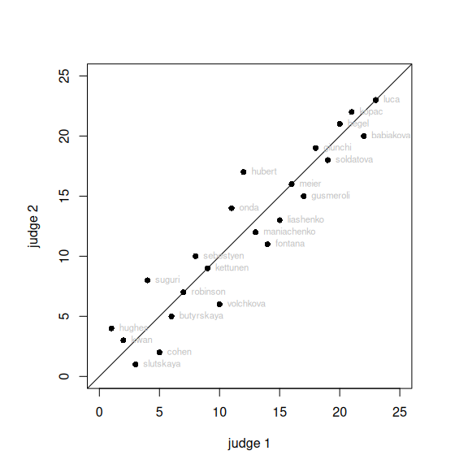

Figure 1: Judge 1 vs judge 2

```r
par(pty='s')  # forces plot to be square
plot(j1,j2,asp=1,pty='s',xlim=c(0,25),ylim=c(0,25),pch=16,xlab='judge 1',ylab='judge 2')
abline(0,1)  # diagonal line
for(i in seq_along(j1)){text(j1[i],j2[i],names(j1)[i],pos=4,col='gray',cex=0.7)}
```

In figure 1, we see general agreement but differences in detail. For example, `hughes` is ranked first by judge 1 and fourth by judge 2. However, other problems are not so easy. Suppose we wish to compare the ranks according to likelihood with the ranks according to some points system.

```r
mL <- skating_maxp  # predefined; use maxp(skating) to calculate ab initio
mL
```

```
##      babiakova     butyrskaya          cohen        fontana
## 5.04723518e-06 5.30446955e-03 9.02414906e-02 3.68328234e-04
##        giunchi      gusmeroli          hegel         hubert
## 1.13732552e-05 8.31691418e-05 9.78563138e-06 2.68983087e-04
##         hughes       kettunen          kopac           kwan
## 2.98316647e-01 1.37641229e-03 2.99666669e-06 2.65505941e-01
##      liashenko           luca    maniachenko          meier
## 5.18862556e-04 1.00000004e-06 8.06879165e-04 2.92808931e-04
##           onda       robinson      sebestyen      slutskaya
## 4.88018960e-04 5.30826157e-03 2.58830213e-03 3.08892999e-01
##      soldatova         suguri      volchkova
## 1.26927514e-05 1.84571521e-02 1.13837922e-03
```

Note that in the above, the competitors’ names are in alphabetical order. We first need to convert strengths to ranks:

```r
mL[] <- rank(-mL)  # minus because ranks orders from weak to strong
mL
```

```
##   babiakova  butyrskaya       cohen     fontana     giunchi
##          21           7           4          14          19
##   gusmeroli       hegel      hubert      hughes    kettunen
##          17          20          16           2           9
##       kopac        kwan   liashenko        luca maniachenko
##          22           3          12          23          11
##       meier        onda    robinson   sebestyen   slutskaya
##          15          13           6           8           1
##   soldatova      suguri   volchkova
##          18           5          10
```

(note that the names are in the same order as before, alphabetical). In the above we see that `slutskya` ranks first, `hughes` second, and so on. Another way of ranking the skaters is to use a Borda-type system: essentially the rowsums of the table (and, of course, the *lowest* score wins):

```r
mP <- rowSums(skating_table)  # 'P' for Points
mP[] <- rank(mP,ties='first') # positive sign here
mP
```

```
##      hughes   slutskaya        kwan       cohen      suguri
##           1           2           3           4           5
##  butyrskaya    robinson   sebestyen    kettunen   volchkova
##           6           7           8           9          10
## maniachenko     fontana   liashenko        onda      hubert
##          11          13          12          14          16
##       meier   gusmeroli   soldatova       hegel     giunchi
##          15          17          18          19          20
##   babiakova       kopac        luca
##          21          22          23
```

It is not at all obvious how to compare `mP` and `mL`. For example, we might be interested in `hegel`. It takes some effort to find that her likelihood rank is 20 and her Borda rank is 19. Function `ordertrans()` facilitates this:

```r
ordertrans(mP,names(mL))
```

```
##   babiakova  butyrskaya       cohen     fontana     giunchi
##          21           6           4          13          20
##   gusmeroli       hegel      hubert      hughes    kettunen
##          17          19          16           1           9
##       kopac        kwan   liashenko        luca maniachenko
##          22           3          12          23          11
##       meier        onda    robinson   sebestyen   slutskaya
##          15          14           7           8           2
##   soldatova      suguri   volchkova
##          18           5          10
```

See above how `ordertrans()` shows the points-based ranks but in alphabetical order, to facilitate comparison with `mL`. We can now plot these against one another:

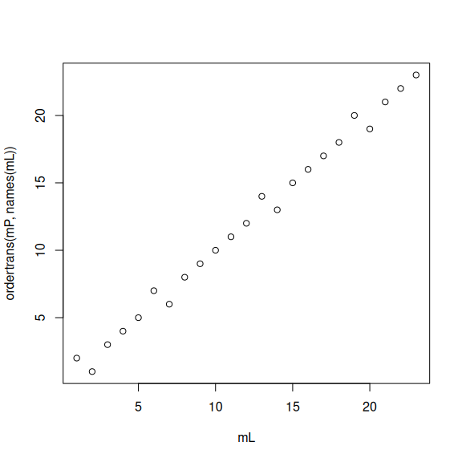

Figure 2: points-based ranks vs likelihood ranks

```r
plot(mL,ordertrans(mP,names(mL)))
```

However, figure 2 is a bit crude. Function `ordertransplot()` gives a more visually pleasing output, see figure 3.

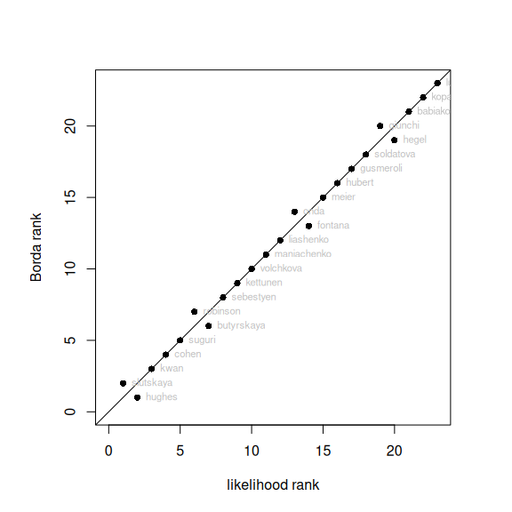

Figure 3: points=based rank vs likelihood rank using `ordertransplot()`

```r
ordertransplot(mL,mP,xlab="likelihood rank",ylab="Borda rank")
```

So now we may compare judge 1 against likelihood:

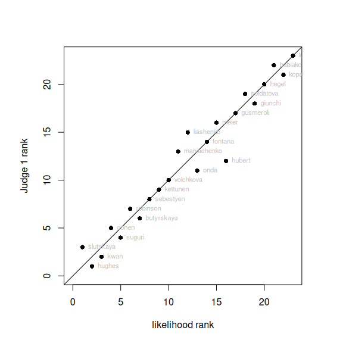

Figure 4: Likelihood rank vs rank according to Judge 1

```r
ordertransplot(mL,j1,xlab="likelihood rank",ylab="Judge 1 rank")
```

In figure 4, looking at the lower-left corner, we see (reading horizontally) that the likelihood method placed Slutskya first, then Hughes second, then Kwan third; while (reading vertically) judge 1 placed Hughes first, then Kwan, then Slutskya.

# References

Hankin, R. K. S. 2017. “Partial Rank Data with the `hyper2` Package: Likelihood Functions for Generalized Bradley-Terry Models.” *The R Journal* 9 (2): 429–39.